# Evaulating Training Set Models and Initial Validation

Niel

April 13, 2015

### Finding the best models

The first plot shows the results from the semi-exhaustive approach to finding the best models. For lesion, the AIC drops steadily until 15 OTUs. After that, the models would not converge. The adenoma models improve steadily all the way to the 30-OTU model. I didn’t want to got any further than 30 OTUs. The AIC of the cancer models bottoms out with 18 OTUs. The raw values are in a table below the plot.

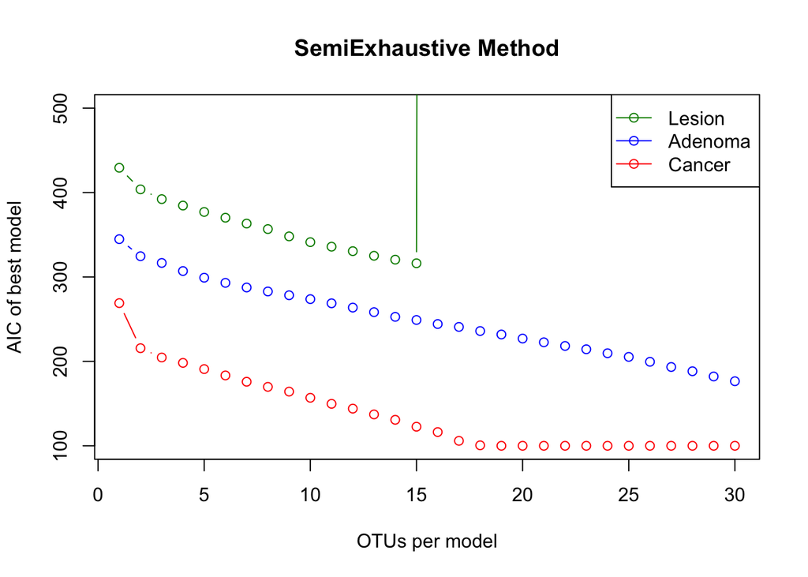

```
##
##
##       canc.aics   ade.aics     les.aics
## ---  ----------  ---------  -----------
##   1    269.0118   344.7837     429.3418
##   2    215.6154   324.5690     403.7654
##   3    204.5973   316.5946     392.1970
##   4    198.2229   307.0141     384.5631
##   5    190.8593   299.1138     377.0121
##   6    183.3509   293.0234     370.1757
##   7    175.8516   287.5042     363.2523
##   8    169.7969   282.8088     356.7155
##   9    164.1853   278.3233     348.0841
##  10    156.8567   273.7358     341.2440
##  11    149.6931   268.8012     335.8615
```

[output cut: 19 more lines]

After using RandomForest to find the 20 best OTUs for each comparison, I tested all possible logit models. Comprared to the Semi-exhaustive approach, the AICs bottom out with fewer OTUs and never get as low. I used the 12-OTU model for cancer, 13-OTU model for adenoma, and the 16-OTU model for lesion.

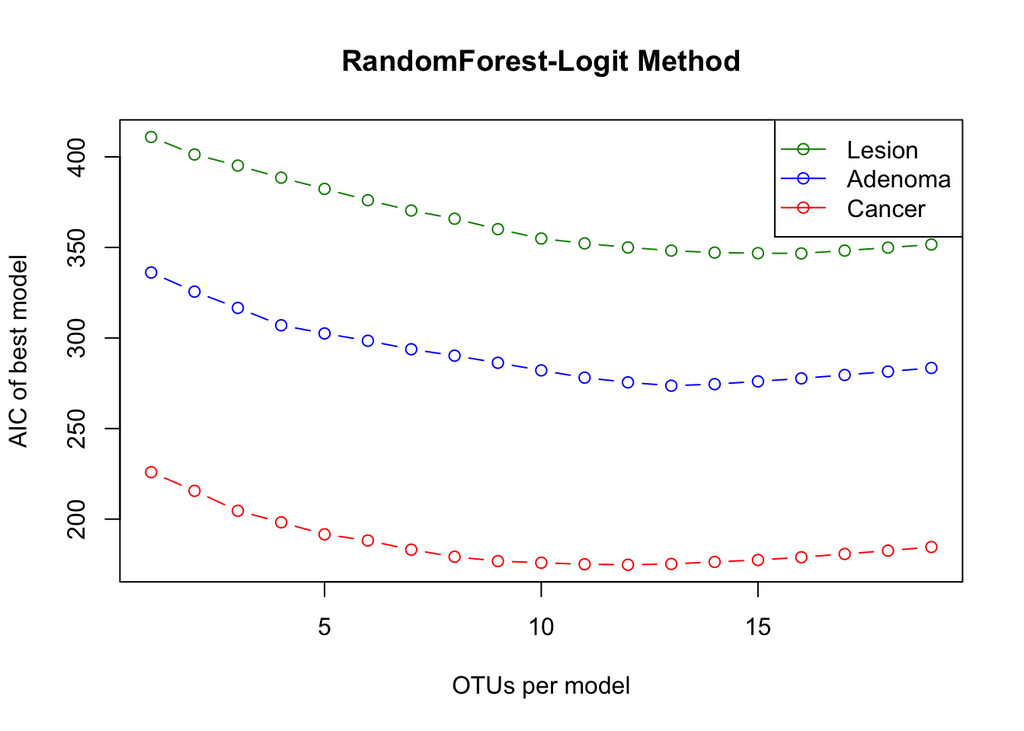

```
##
##
##       canc.aics   ade.aics   les.aics
## ---  ----------  ---------  ---------
##   1    225.9110   336.1558   410.9746
##   2    215.6154   325.5992   401.3184
##   3    204.5973   316.5946   395.1864
##   4    198.2229   307.0141   388.5095
##   5    191.5891   302.5109   382.3280
##   6    188.1834   298.4742   376.0819
##   7    183.1356   293.7804   370.3765
##   8    179.2171   290.2381   365.8506
##   9    176.8136   286.3081   360.0981
##  10    175.9092   282.1239   354.9171
##  11    175.0620   278.1092   352.2279
##  12    174.7927   275.5173   349.9964
##  13    175.2321   273.6469   348.2445
##  14    176.3666   274.5198   347.1429
##  15    177.4445   276.0314   346.8421
##  16    178.9371   277.7000   346.6868
##  17    180.7580   279.5747   348.2489
##  18    182.5907   281.4834   349.8833
##  19    184.5790   283.4563   351.6144
```

### Cancer vs Normal

Below is a ROC curve using the models cancer models I selected above. The Random Forest classifier (in green) works poorly compared to the logit models. The logit model that was guided by RF feature selection (Logit(RF) in yellow) uses 12 OTUs and does quite well, but not as well as FIT. The logit model from the semi-exhaustive approach does very well, but is probably more overfit since it contains 18 OTUs.

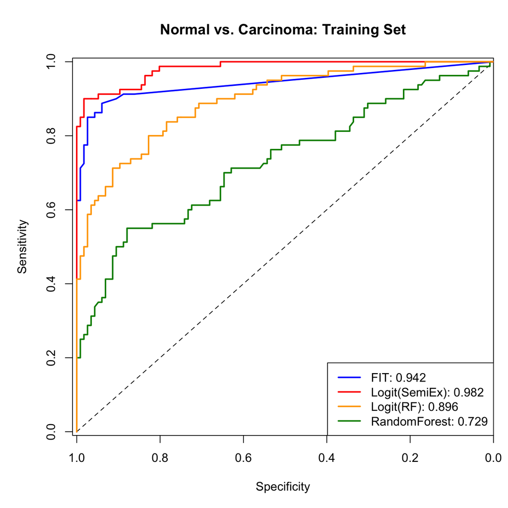

Below is the exact same figure as above, but I’ve added in curves with dashed lines for the models run on the testing set. The RF classifier does just as well, if not better, on the testing set. This is promising. As you suggested, I will try running random forest on the whole dataset. The two logit models (red and yellow) do equally well on the testing set. I favor the RF feature selection method since its much quicker and there’s less of a difference in performance between the training and testing sets.

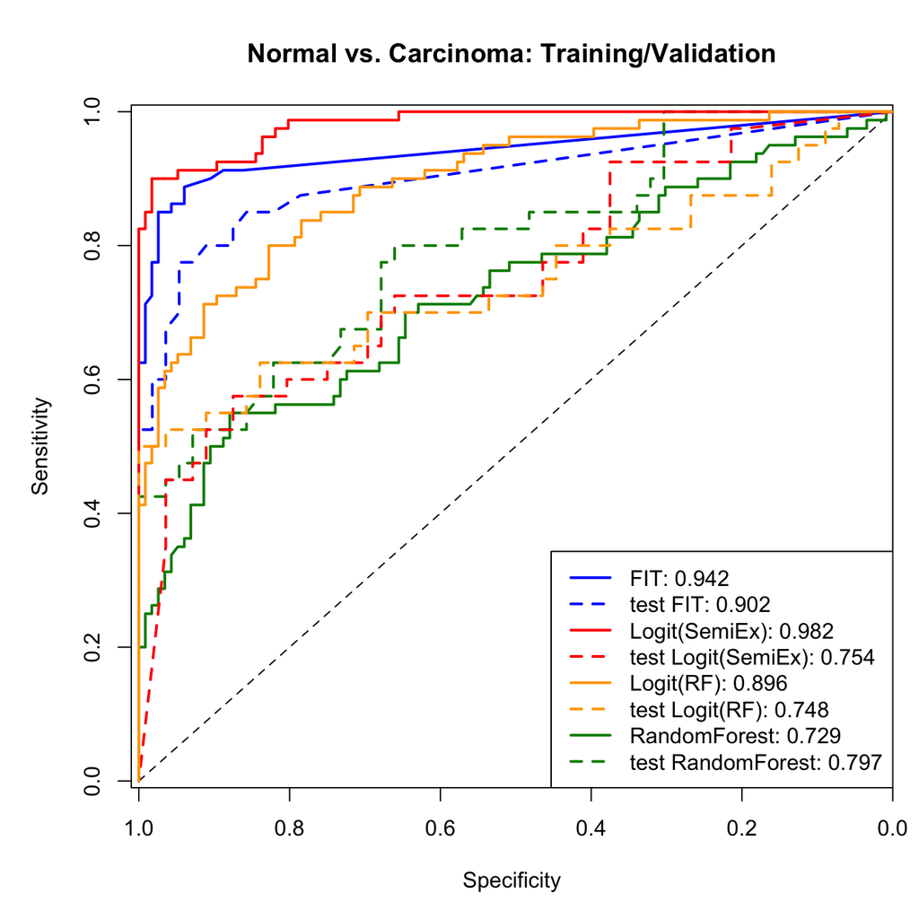

### Adenoma vs Normal

For adenomas, the RF classifier is terrible. The logit models both do better than FIT. The red model contains 30 OTUs. The yellow contains 13.

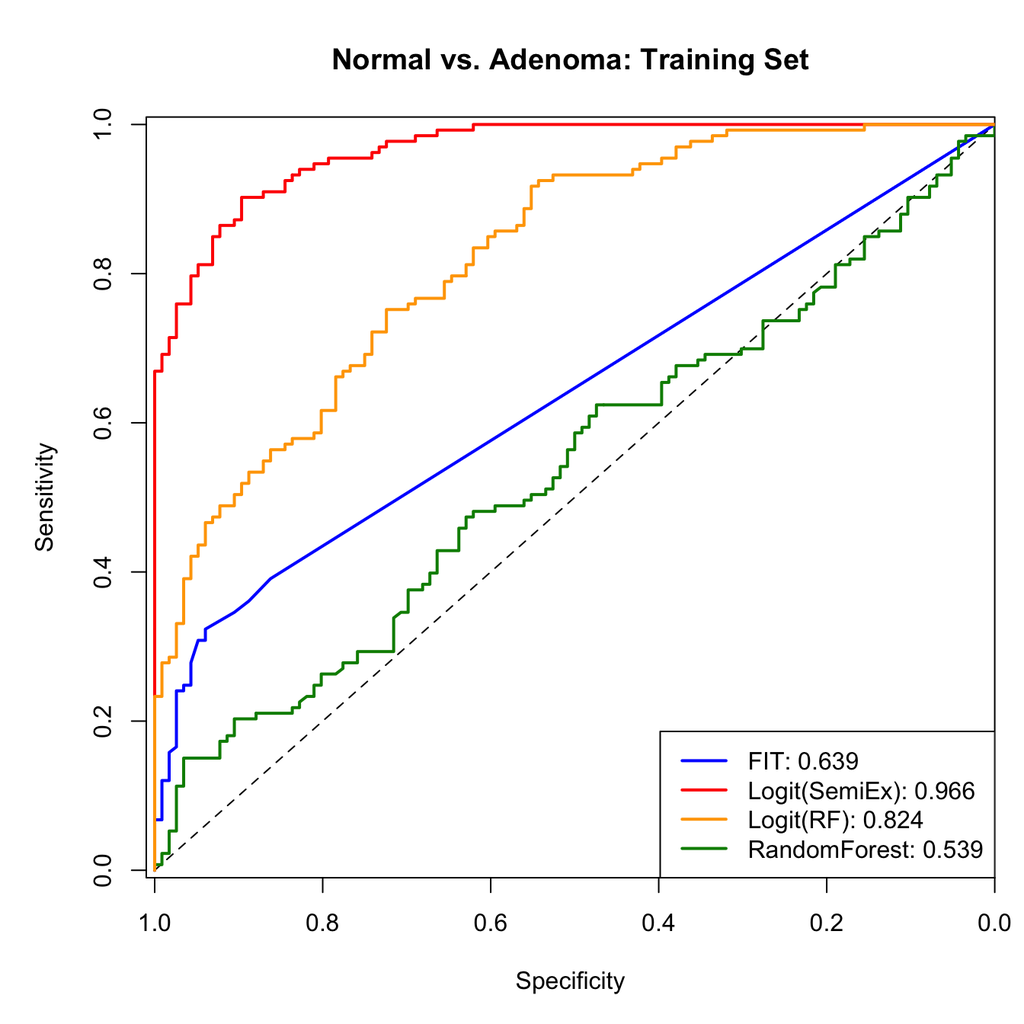

Clearly the models were overfit, since they work terribly on the testing set. The RF-guided method does slightly better. I’ll try using fewer OTUs so that its not so overfit.

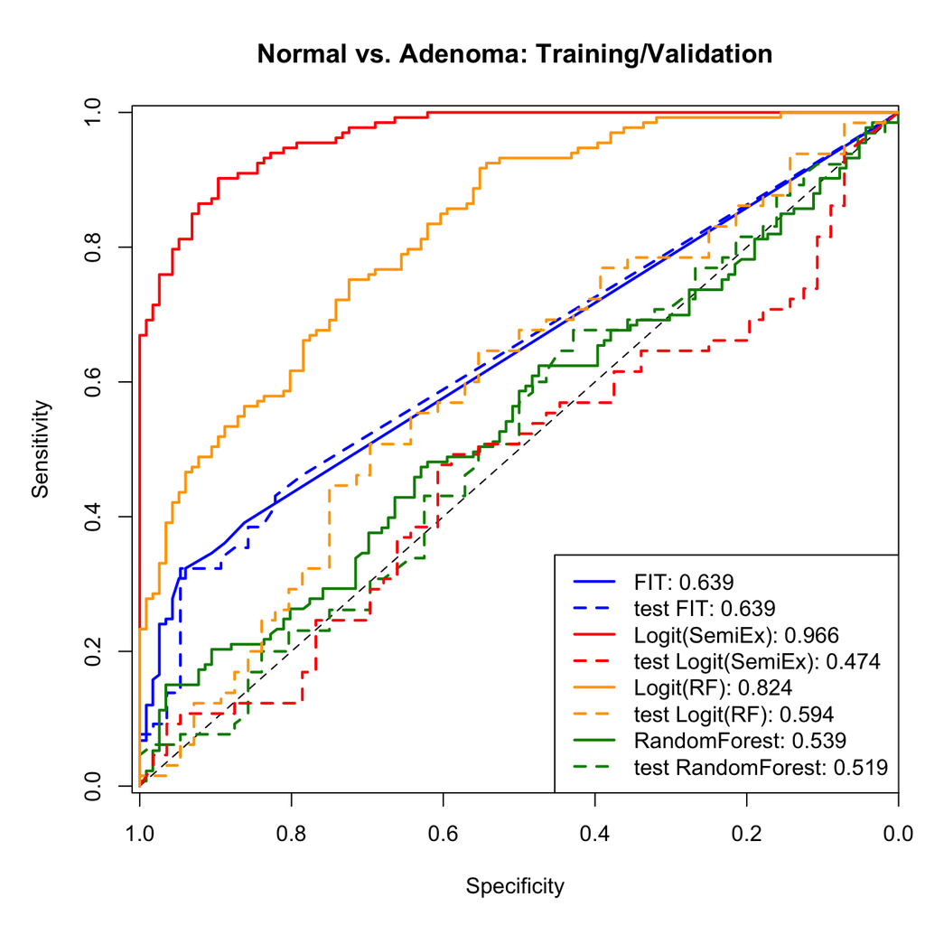

### Lesion vs Normal

The results for lesion are similar to adenoma, except that there is a higher bar for beating FIT. Again, the RF-guided logit models are marginally better than the others.

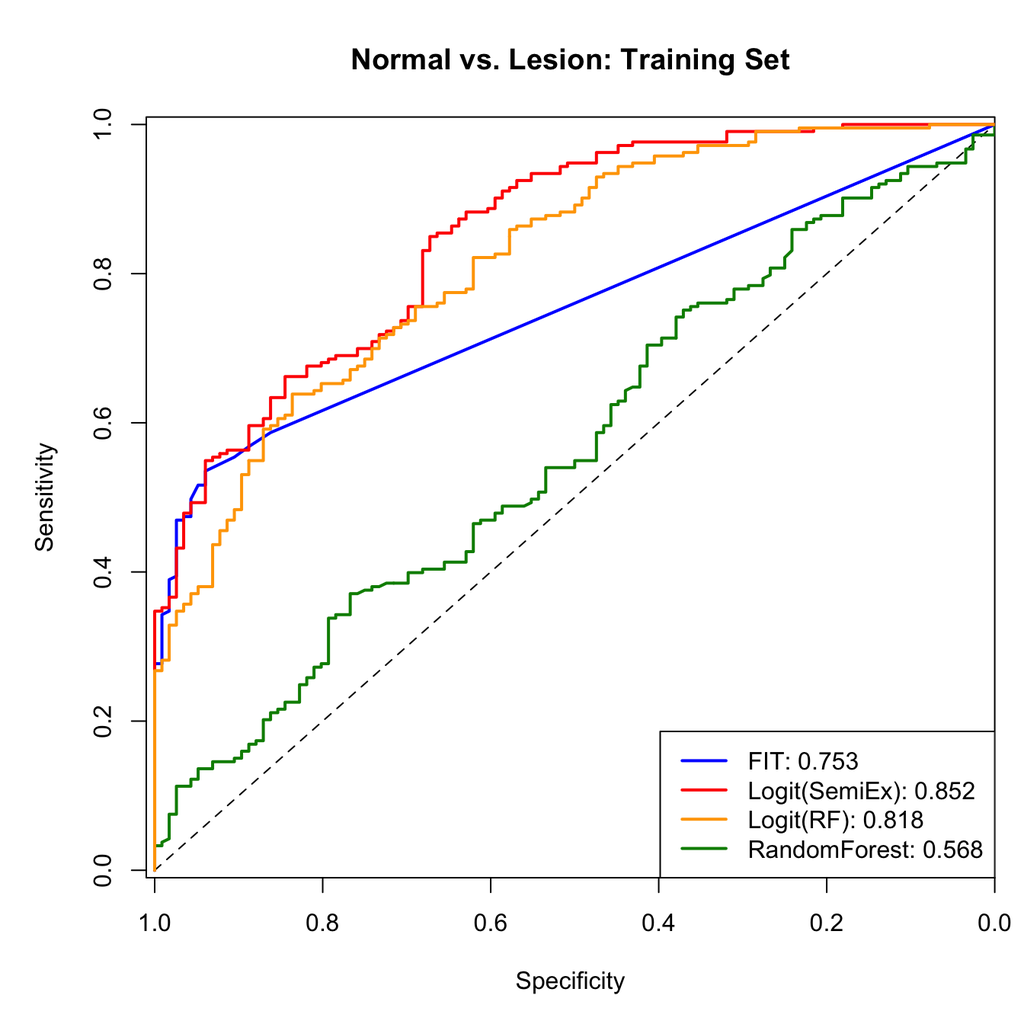

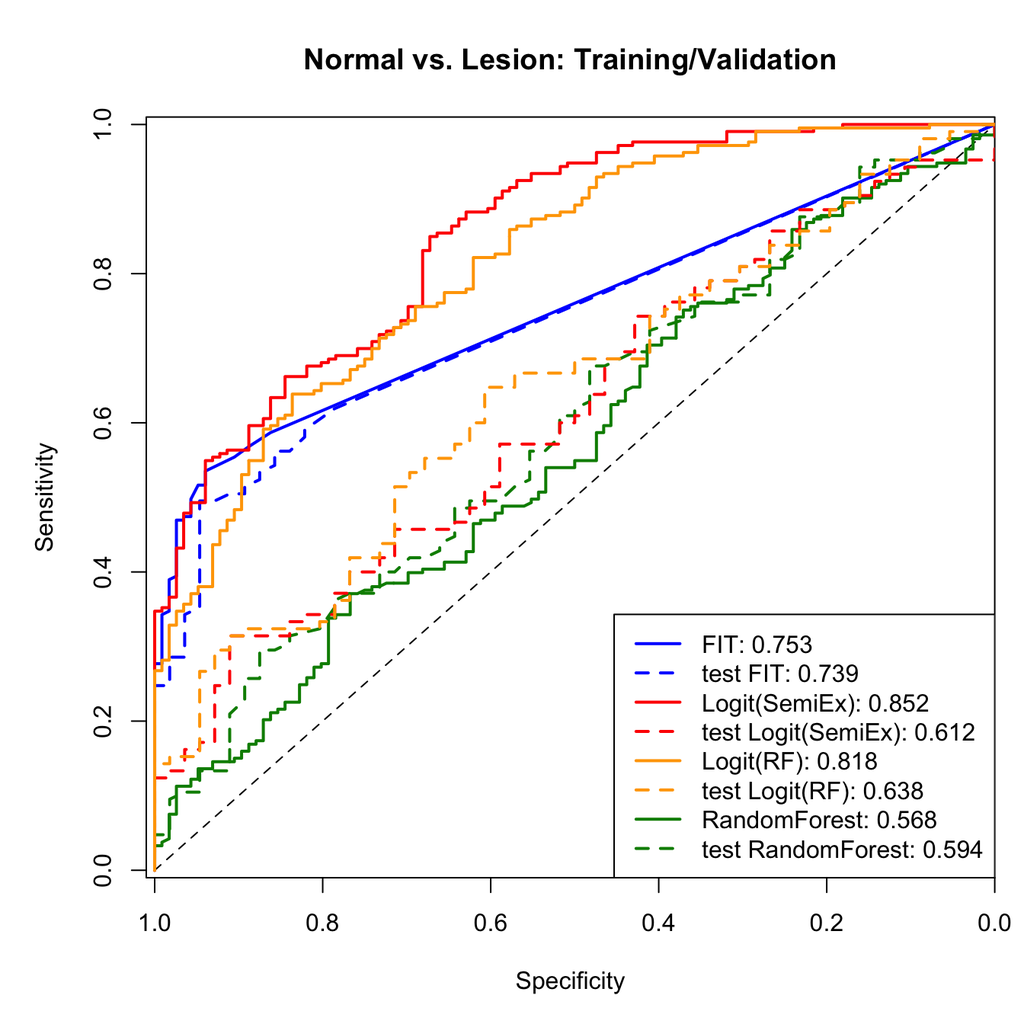

### Conclusions

There is some potential for using a Random Forest model for the cancer vs normal comparison, however random forest does poorly on the other comparisons. I think the most promising method is the logit model guided by RF feature selection. I will try cutting down the number of OTUs to see where we get the best models with the least overfitting.